# ProsperLoanData EDA by Sylvia.Xie

```
##  [1] "ListingKey"
##  [2] "ListingNumber"
##  [3] "ListingCreationDate"
##  [4] "CreditGrade"
##  [5] "Term"
##  [6] "LoanStatus"
##  [7] "ClosedDate"
##  [8] "BorrowerAPR"
##  [9] "BorrowerRate"
## [10] "LenderYield"
## [11] "EstimatedEffectiveYield"
## [12] "EstimatedLoss"
## [13] "EstimatedReturn"
## [14] "ProsperRating..numeric."
## [15] "ProsperRating..Alpha."
```

[output cut: 66 more lines]

```
##                ListingKey ListingNumber           ListingCreationDate
## 1 1021339766868145413AB3B        193129 2007-08-26 19:09:29.263000000
## 2 10273602499503308B223C1       1209647 2014-02-27 08:28:07.900000000
## 3 0EE9337825851032864889A         81716 2007-01-05 15:00:47.090000000
## 4 0EF5356002482715299901A        658116 2012-10-22 11:02:35.010000000
## 5 0F023589499656230C5E3E2        909464 2013-09-14 18:38:39.097000000
## 6 0F05359734824199381F61D       1074836 2013-12-14 08:26:37.093000000
##   CreditGrade Term LoanStatus          ClosedDate BorrowerAPR BorrowerRate
## 1           C   36  Completed 2009-08-14 00:00:00     0.16516       0.1580
## 2               36    Current                         0.12016       0.0920
## 3          HR   36  Completed 2009-12-17 00:00:00     0.28269       0.2750
## 4               36    Current                         0.12528       0.0974
## 5               36    Current                         0.24614       0.2085
## 6               60    Current                         0.15425       0.1314
##   LenderYield EstimatedEffectiveYield EstimatedLoss EstimatedReturn
```

[output cut: 174 more lines]

这份数据集包括113,937份贷款数据，包括81个变量，其中包括数字、逻辑变量等不同类型的变量，分别描述的每一项贷款的类别、数额、利息等数据。

# Univariate Plots Section

```
##    Min. 1st Qu.  Median    Mean 3rd Qu.    Max.
##   12.00   36.00   36.00   40.83   36.00   60.00
```

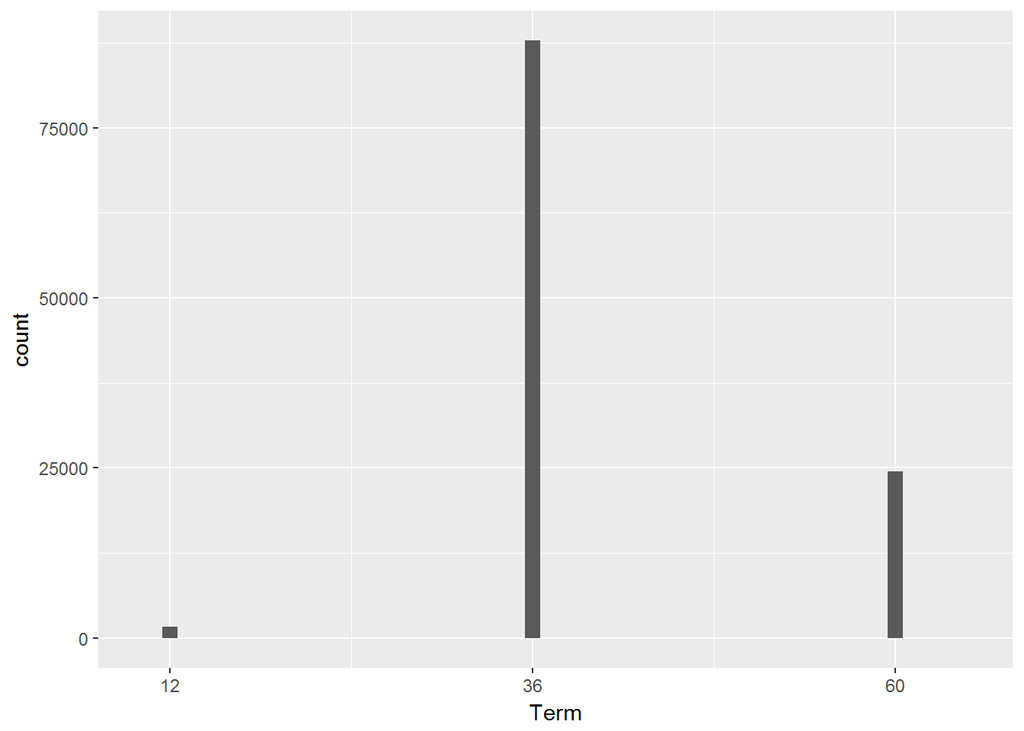

显然，贷款的期限集中在12、36、60这三个月份。

```
##    Min. 1st Qu.  Median    Mean 3rd Qu.    Max.
##    1000    4000    6500    8337   12000   35000
```

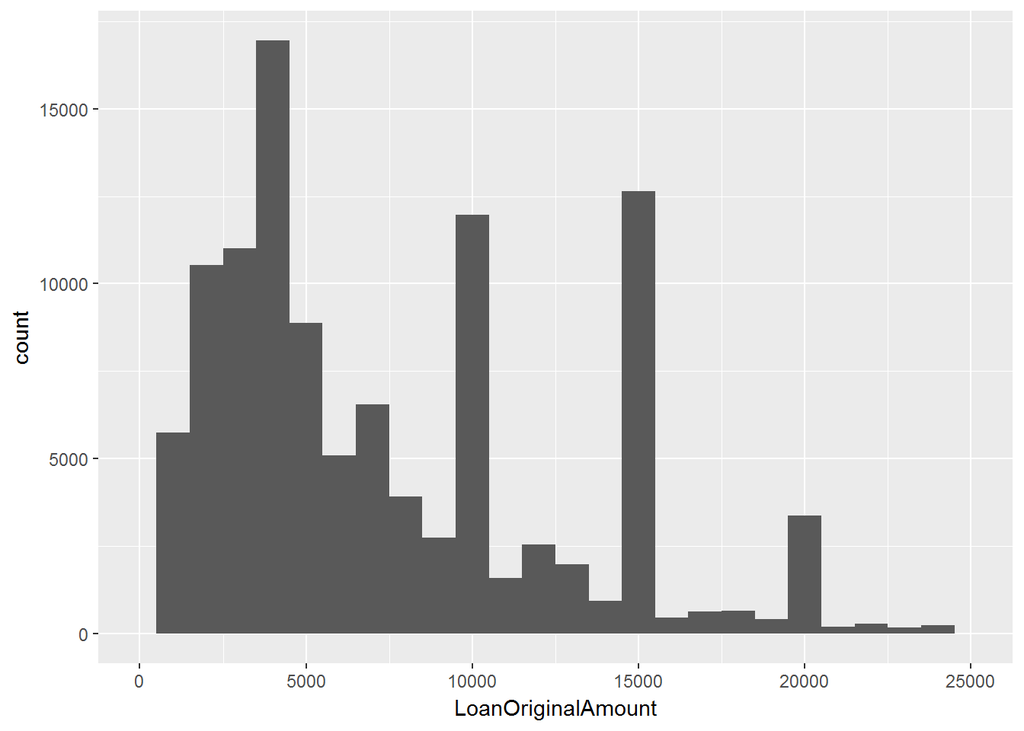

观察结果，贷款的数额75%均集中在12000以内，在10000、15000、20000等区域出现高峰值，后面将继续研究出现的原因。

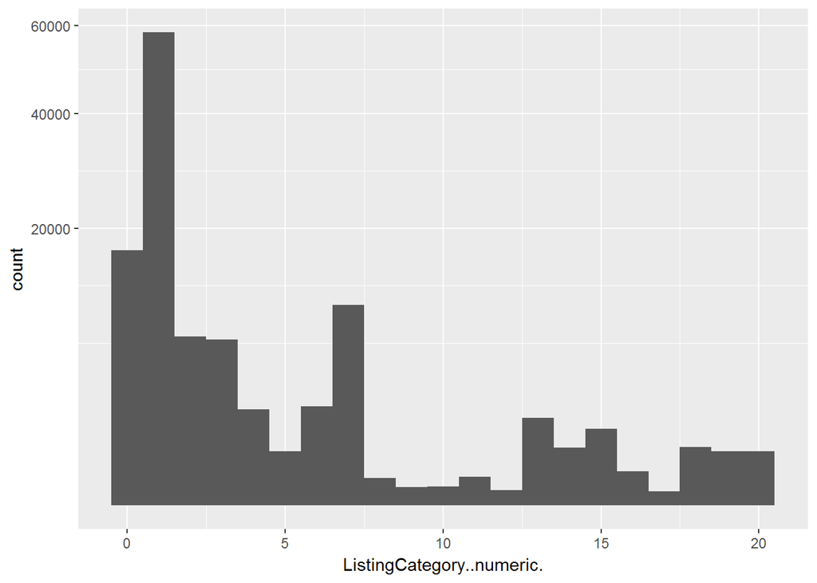

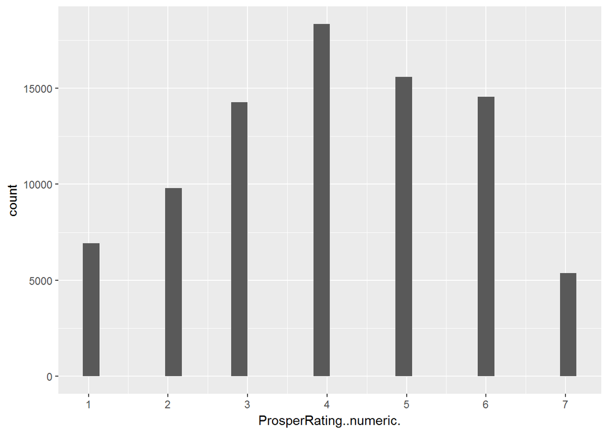

当前市场繁荣等级（经济环境）呈现类似于正态分布的情况，以等级4为中心，两边递减。

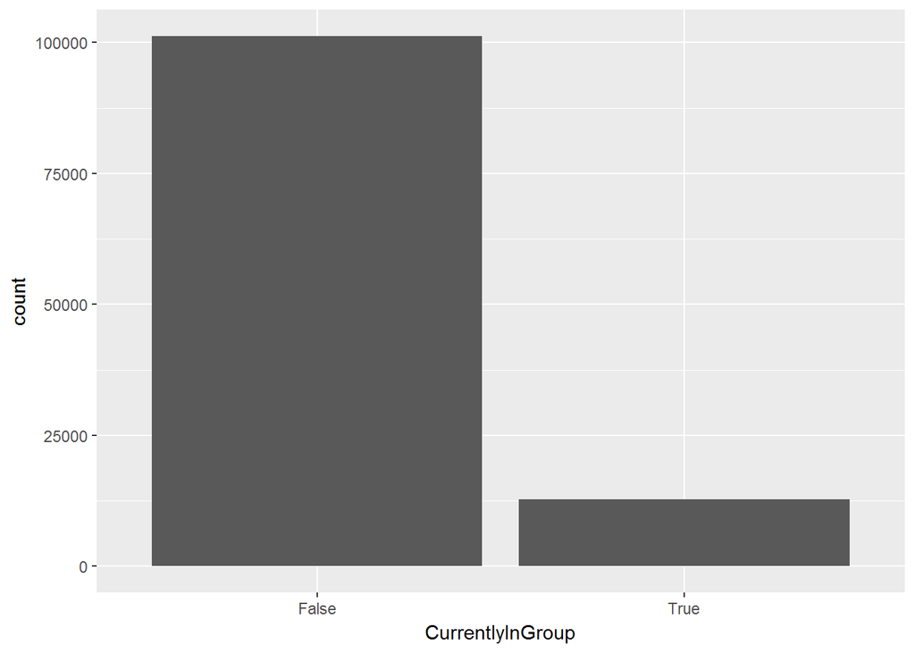

显然，贷款方更愿意借款给第一次借款/已经偿还了上次贷款（不再在列表内）的借款人。

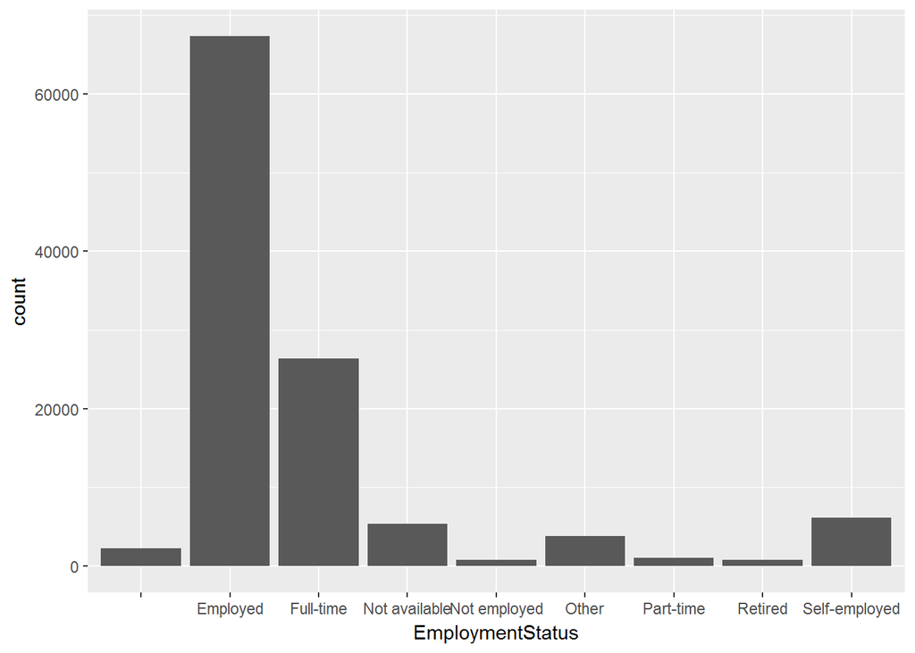

忽略未填写的状态，拥有全职工作/就职状态的借款人更容易贷款。

数据集的数据结构较为简单，主要问题是要理解81个变量，其中包括数字型、逻辑型等的含义。 大部分变量进行单变量分析后，可以看到有集中趋势，可以反映借款人、贷款方以及当前市场环境的特点，如拥有全职工作的借款人更容易贷款，数据将会集中分布在该特性下。 数据集中有许多的变量可能并不会在分析中用到，但是他能帮助我更好地理解数据，如贷款的时间、收益损失等。 在单变量分析中，我暂时没有创建新的变量，只是对数据集会作出筛选子集。 在该数据集的单变量分析中，我研究了几个我较为感兴趣的变量分布特征，可以明显看到有集中分布的特点，同时也符合我的猜想。

# Bivariate Plots Section

接下来让我们观察一下借款人能够贷款得到的数额与什么因素有关：

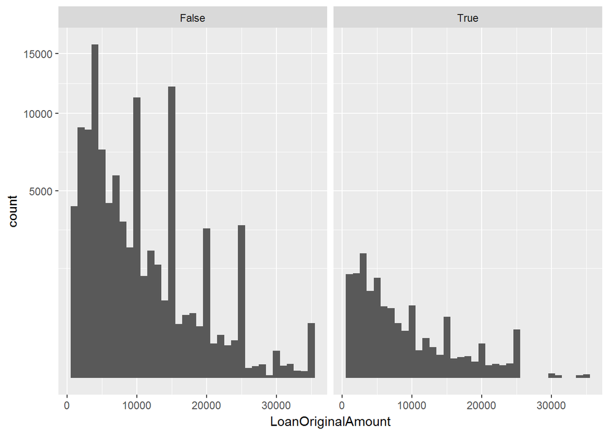

显然，贷款公司似乎更愿意贷款给第一次借款/已经成功偿还了上一次贷款的人。

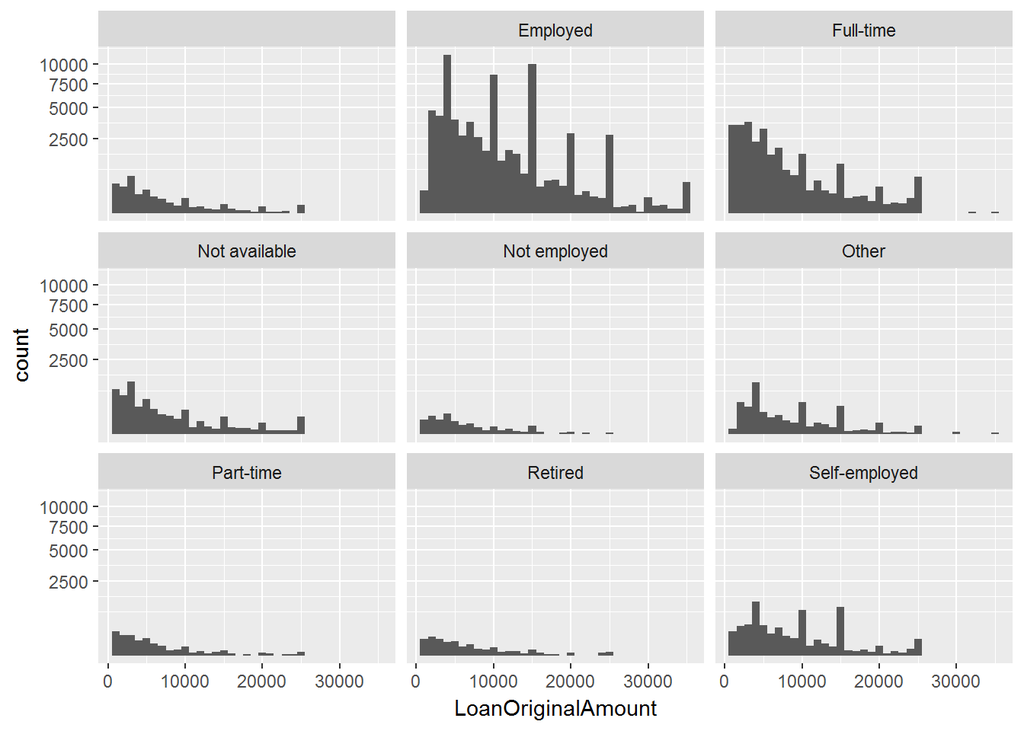

从图上可以清晰地看到，被雇佣/拥有全职工作的借款人更容易借款。

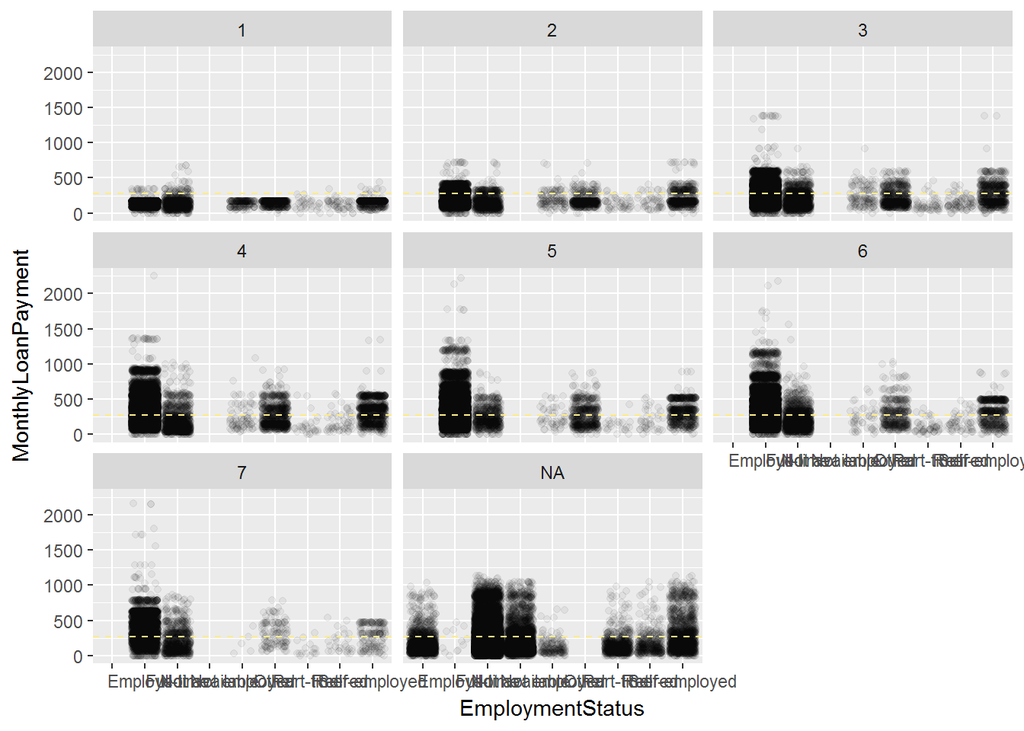

而且无论当前市场的经济环境如何，对于已经就业/全职的借款人来说,他们更加容易偿还贷款，对于设定的每月偿还数额的上限更大。

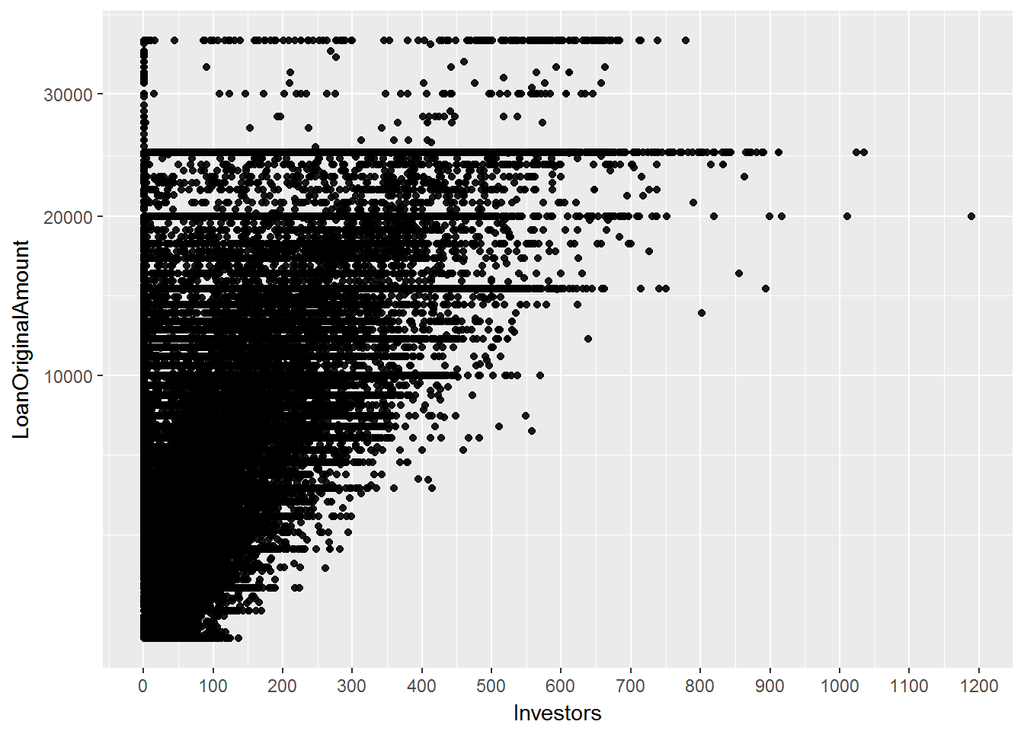

随着贷款金额的增加，需要投资人的投资也越来越多，但同时也存在多金额-少投资人的情况存在。

```
## # A tibble: 6 x 4
##   ProsperRating..numeric. median_LoanOriginalAmount
##                     <int>                     <dbl>
## 1                       1                      4000
## 2                       2                      4000
## 3                       3                      6100
## 4                       4                     10000
## 5                       5                     10000
## 6                       6                     10000
## # ... with 2 more variables: mean_LoanOriginalAmount <dbl>, n <int>
```

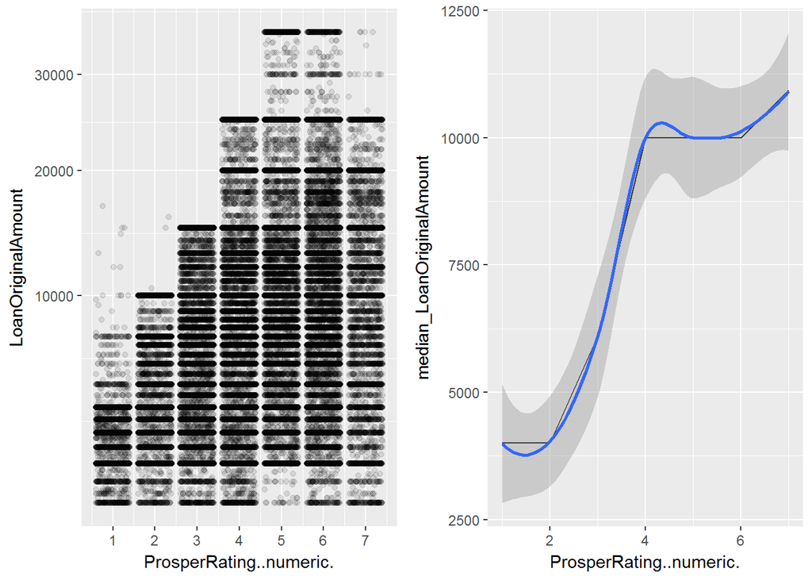

创建新的数据框，观察贷款数额的中位数（更能反映平均水平在这里） 市场繁荣等级越高（即经济环境越好的情况下），借款人更容易接到更大数额的借款，观测其各等级中位数变化情况也符合这种猜测。

那么投资者的增减是否也会和市场繁荣等级有关呢？

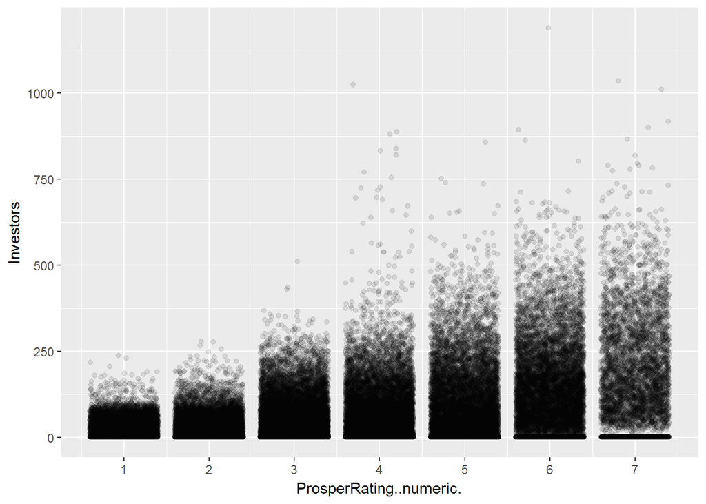

显然，市场越繁荣，贷款市场也能吸引到越来越多的投资。 那么对于投资者来说，什么因素是最吸引他们的呢？

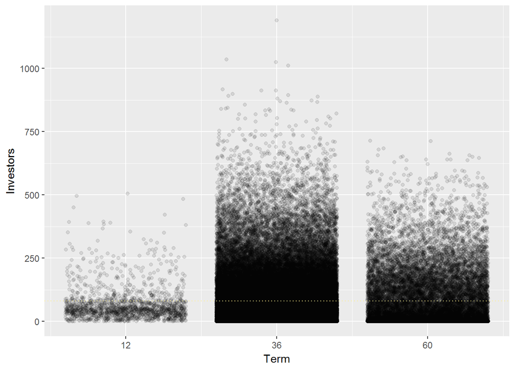

显然投资似乎更加偏爱投资中长期的贷款。

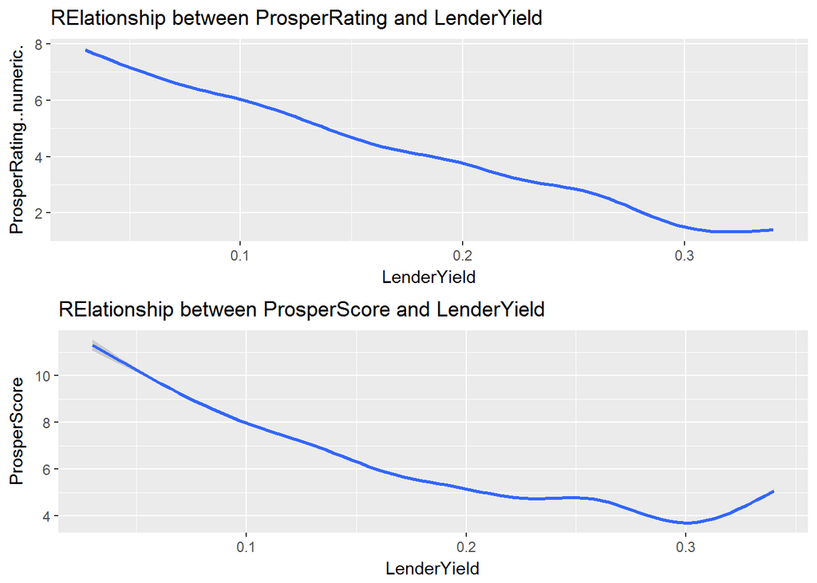

```
##
##  Pearson's product-moment correlation
##
## data:  pl_by_rosperRating..numeric.$LenderYield and pl_by_rosperRating..numeric.$ProsperRating..numeric.
## t = -917.52, df = 84851, p-value < 2.2e-16
## alternative hypothesis: true correlation is not equal to 0
## 95 percent confidence interval:
##  -0.9537315 -0.9524993
## sample estimates:
##        cor
## -0.9531194
```

```
##
##  Pearson's product-moment correlation
##
## data:  pl$LenderYield and pl$ProsperScore
## t = -249.01, df = 84851, p-value < 2.2e-16
## alternative hypothesis: true correlation is not equal to 0
## 95 percent confidence interval:
##  -0.6536541 -0.6458788
## sample estimates:
##        cor
## -0.6497835
```

显然，收率率与市场繁荣程度呈反比例的关系，风险则与收益率呈正比例关系，这说明了，当市场环境越繁荣时，能够吸引到的投资者越多，风险较低，同时利率较低；在衰落的市场下，需要高收益吸引投资者，但同时风险也加大。下面将会继续分析三者的关系。这组关系也是我目前观察到最强的线性关系。

# 1.Talk about some of the relationships you observed in this part of the investigation. How did the feature(s) of interest vary with other features in the dataset?

经过单变量分析中观察出的关于借款人的职业、贷款数额等变量具有集中分布的特点，我提出了几个假设，如贷款数额的大小受到借款人职业状态的限制、投资者越多是否意味着能够贷款的数额也会随之增加。 经过散点图等可视化图形分析之后，我们可以清晰地看到，处于就业状态或者拥有全职工作的借款人能够借到钱远大于平均水平，特别是就业状态下.

# 2.Did you observe any interesting relationships between the other features (not the main feature(s) of interest)?

比如像在探索投资者数量和贷款数额关系的时候，我发现投资者越多，贷款数额越大，但是也存在特殊情况是投资者少但是可贷款数额大的情况，或者投资者多但是可贷款数额小的情况，因此我猜想可能与借贷当时的市场环境有关。

# 3.What was the strongest relationship you found?

# Multivariate Plots Section

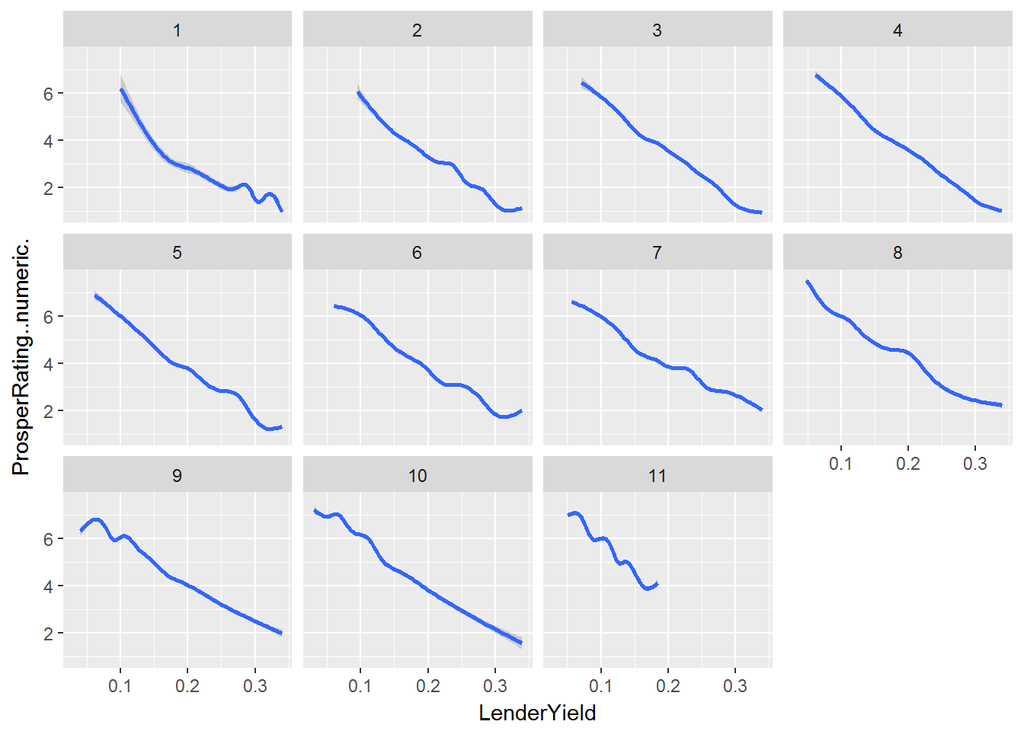

我们可以看到，市场繁荣等级与贷款收益率呈反比例关系，市场越衰落，就越需要高收益率来吸引新的投资者参与进市场，投资者面临的而风险也随着收益率的增加而增大。我们可以从图上看见，不同的风险因素下，越繁荣的市场，收益率相比其他类型的市场，收益率更低些。

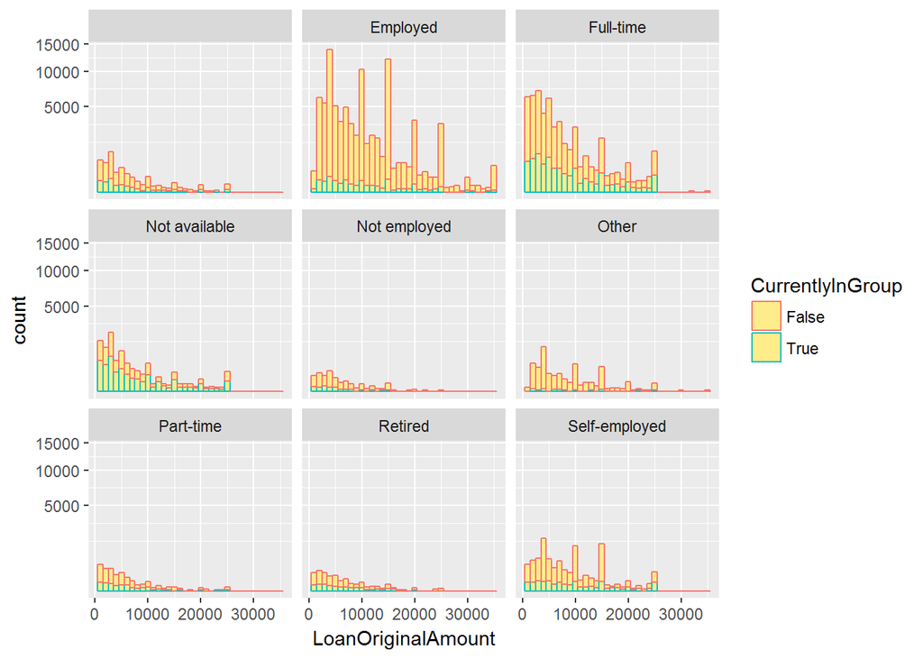

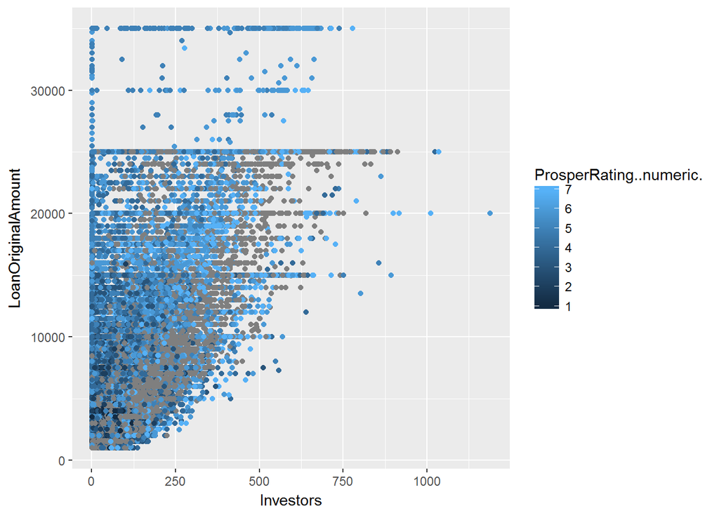

繁荣等级高的点（浅色）更多地分布在高数额-多投资者的地方。

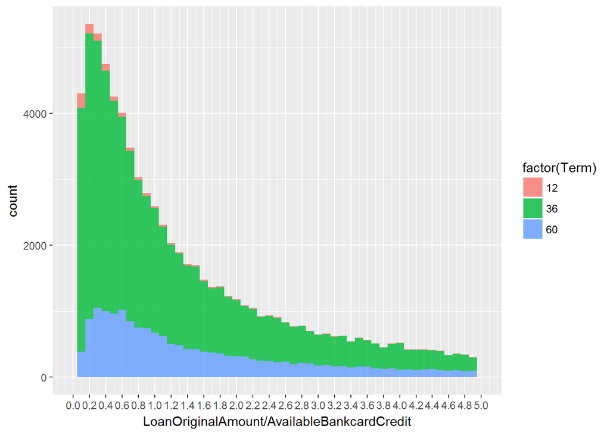